# Сравнение эффективности методов обучения методом дисперсионного анализа

Заходякин Г.В., postlogist@gmail.com

30.01.2017

## Введение

Дисперсионный анализ (analysis of variance, ANOVA) позволяет установить отличия между средними значениями нескольких генеральных совокупностей. В данном примере дисперсионный анализ применяется для сравнения эффективности различных методов анализа текстов, которым обучали студентов Carmel College (Аукленд, Новая Зеландия) в рамках программы развития исследовательских навыков.

На рисунке показана схема проведения эксперимента.

[figure not shown]

Схема эксперимента

Все студенты были разделены на 4 группы. В первой группе их обучали методу картирования понятий в тексте с помощью диаграмм. Во второй группе перед подробным изучением текста студентов просили ознакомиться с его структурой путем беглого чтения (сканирования) заголовков и вводных разделов. В третьей группе одновременно использовались оба этих метода. Четвертая группа была контрольной, ни один из этих методов анализа не применялся. Обучение проводилось в течение 6 недель. Перед началом программы и по ее окончании студенты проходили тесты на понимание текста (Gapadol Reading Comprehension Test), который дает оценку возраста (степени зрелости) читателя.

В файле `reading.txt` содержатся данные об изменении результатов теста после обучения для каждого студента. Положительное число означает улучшение результатов, отрицательное - ухудшение. Также указана принадлежность студента к одной из экспериментальных групп.

Данные взяты из Wild C.J., Seber A.F. Chance Encounters. A First Course in Data Analysis and Inference, Wiley, 2000. - p. 435.

## Подготовка

```r
suppressMessages(library(readr)) # считывание данных из текстовых файлов
suppressMessages(library(tidyverse)) # манипулирование данными
suppressMessages(library(ggplot2)) # визуализация
suppressMessages(library(scales)) # Процентный формат для осей графиков
```

Данные сохранены в “плоском” табличном формате. Разделителями столбцов являются табуляции. Десятичный разделитель - точка.

Первая строка содержит заголовки столбцов. Для считывания данных из текстового файла можно воспользоваться либо встроенными функциями: `read.table()`, `read.csv()` (в этом семействе несколько функций для разных форматов), либо аналогичными функциями из пакета `readr`. Функции из пакета `readr` работают быстрее и в сложных случаях дают больше возможностей для настройки формата данных. Изучить их подробнее можно в разделе [Data Import](http://r4ds.had.co.nz/data-import.html) книги R for Data Science.

```r
reading <- read_tsv('data/reading.txt')
glimpse(reading)
```

```
## Observations: 50
## Variables: 3
## $ increase <dbl> 0.1, 3.2, 4.3, -0.5, 1.9, 3.3, 2.5, 3.6, 0.4, 2.3, -1...
## $ method   <chr> "Both", "Both", "Both", "Both", "Both", "Both", "Both...
## $ methcode <dbl> 1, 1, 1, 1, 1, 1, 1, 1, 1, 1, 1, 1, 1, 1, 1, 1, 1, 1,...
```

Для управления порядком вывода групп при анализе создадим факторную переменную.

```r
reading <- reading %>%
  mutate(methodf = factor(method,
                            levels = c('Neither', 'Scan', 'Map', 'Both')))
```

## Разведочный анализ

Сравним изменение результатов теста в разных группах.

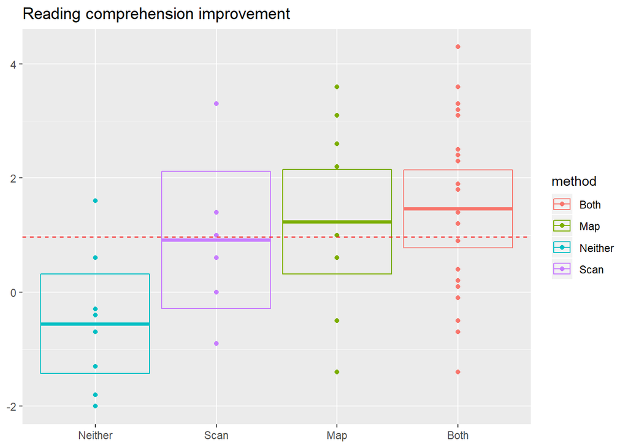

```r
# На графике
ggplot(data = reading, aes(y = increase, x = methodf, colour = method)) +
  geom_point()  +
  labs(title = 'Reading comprehension improvement', x = NULL, y = NULL) +
  stat_summary(fun.data = 'mean_cl_normal', geom = 'crossbar') +
  geom_hline(aes(yintercept = mean(increase)), color = 'red', linetype = 'dashed')
```

```r
# В табличном виде
reading %>%
  group_by(methodf) %>%
  summarise(mean_increase = round(mean(increase), 2))
```

```
## # A tibble: 4 x 2
##   methodf mean_increase
##   <fct>           <dbl>
## 1 Neither         -0.56
## 2 Scan             0.91
## 3 Map              1.23
## 4 Both             1.46
```

Точки показывают распределение результатов отдельных студентов в каждой группе. Ящики показывают среднее улучшение результатов теста в каждой группе и 95% доверительный интервал. Горизонтальная линия - среднее улучшение для всех студентов, вместе взятых.

По графику видно, что все методы дают улучшение по сравнению с контрольной группой, однако различие между методами минимальное.

## Проверка статистических гипотез

### Существует ли различие между группами?

В нашем распоряжении - 4 независимые выборки (наблюдения в одной выборке никак не связаны с наблюдениями в другой выборке), поэтому необходимо применять однофакторный дисперсионный анализ (One-Way ANOVA). Фактором является группа (метод анализа текста), а зависимой переменной - улучшение результатов в тесте на понимание текста.

Совокупностями в данном случае будут все студенты с аналогичными испытуемым характеристиками, которые будут обучаться соответствующим методом.

**Нулевая гипотеза:** *Среднее улучшение во всех группах одинаково* (нет отличий между эффективностью методов).

**Альтернативная гипотеза:** *Среднее улучшение отличается по крайней мере для двух групп* (есть отличия между эффективностью методов).

Для проверки гипотезы используется тестовая статистика:

$$F = MS_{B} / MS_{W},$$

где $MS_{B}$ и $MS_{W}$ - соответственно **межгрупповая дисперсия** (вычисляется на основе групповых средних и общего среднего) и **внутригрупповая дисперсия** (вычисляется на как средневзвешенное оценок дисперсии в отдельных группах). При истинности $H_0$ не должно быть разницы между средними групп, т.е. $MS_{B} = 0$ и $F = 0$.

Для применения дисперсионного анализа в R есть встроенная функция: `aov()`.

```r
reading_anova <- aov(increase ~ methodf, data = reading)
summary(reading_anova)
```

```
##             Df Sum Sq Mean Sq F value  Pr(>F)
## methodf      3  27.06   9.021   4.445 0.00798 **
## Residuals   46  93.35   2.029
## ---
## Signif. codes:  0 '***' 0.001 '**' 0.01 '*' 0.05 '.' 0.1 ' ' 1
```

В этом примере использована запись критерия в виде **формулы**: запись `increase ~ methodf` означает: *Улучшение в зависимости от группы*.

Левая часть формулы (до тильды) содержит зависимую переменную (`increase`), а правая часть - факторы, влияющие на эту переменную (`methodf`).

В таблице дисперсионного анализа указаны суммы квадратов (Sum Sq) и дисперсия (Mean Sq) - межгрупповые, т.е. объясненные влиянием фактора (methodf) и внутригрупповые (Residuals), а также степени свободы. Наблюдаемое значение F-статистики критерия - $F = 4.445$. Уровень значимости $p = 0.008 < 0.05$.

Низкая вероятность получения наблюдаемого отношения межгрупповой и внутригрупповой дисперсии позволяет отвергнуть нулевую гипотезу в пользу альтернативной. Среднее улучшение результатов теста по крайней мере в двух группах отличается.

### В каких группах результаты теста отличаются?

Для того, чтобы выяснить, в каких именно группах отличаются результаты теста, необходимо применить одну из процедур множественных сравнений (post-hoc tests, multiple comparisons). Процедуры множественных сравнений, в отличие от t-критериев, содержат поправки, позволяющие снизить вероятность ошибки I рода (нуль-гипотеза отвергнута ошибочно, ложноположительных исход).

**Метод Тьюки (Tukey Honestly Significant Distance, Tukey HSD)** реализован встроенной функцией `TukeyHSD()`.

```r
options(digits = 3)
TukeyHSD(reading_anova)
```

```
##   Tukey multiple comparisons of means
##     95% family-wise confidence level
##
## Fit: aov(formula = increase ~ methodf, data = reading)
##
## $methodf
##               diff    lwr  upr p adj
## Scan-Neither 1.470 -0.444 3.38 0.186
## Map-Neither  1.789  0.115 3.46 0.032
## Both-Neither 2.015  0.512 3.52 0.005
## Map-Scan     0.319 -1.487 2.12 0.965
## Both-Scan    0.545 -1.103 2.19 0.815
## Both-Map     0.226 -1.137 1.59 0.971
```

p-значения и доверительные интервалы скорректированы (увеличены) таким образом, чтобы общая вероятность получить ошибку I рода в результате всех сравнений была 5%.

Статистически значимые отличия от контрольной группы наблюдаются только для метода картирования и сочетания методов. Различия в эффективности методов анализа текста статистически не значимы.

Для сравнения, рассчитаем p-значения без поправки на множественные сравнения.

Функция `with()` не обязательна, но она позволяет использовать имена столбцов в наборе данных напрямую, т.е. не писать `reading$increase`.

```r
with(reading,
     pairwise.t.test(increase, methodf,
                     p.adjust.method = 'none')
     )
```

```
##
##  Pairwise comparisons using t tests with pooled SD
##
## data:  increase and methodf
##
##      Neither Scan  Map
## Scan 0.046   -     -
## Map  0.007   0.640 -
## Both 8e-04   0.383 0.661
##
## P value adjustment method: none
```

Результаты множественных сравнений без поправки использовать нельзя, т.к. велика вероятность ложноположительного исхода.

Существует несколько процедур множественных сравнений, отличающихся по степени консервативности. Наиболее консервативной считается **процедура Бонферрони**, в которой при проведении $m$ попарных сравнений каждое из p-значений умножается на $m$.

```r
with(reading,
     pairwise.t.test(increase, methodf,
                     p.adjust.method = 'bonferroni')
     )
```

```
##
##  Pairwise comparisons using t tests with pooled SD
##
## data:  increase and methodf
##
##      Neither Scan  Map
## Scan 0.278   -     -
## Map  0.039   1.000 -
## Both 0.005   1.000 1.000
##
## P value adjustment method: bonferroni
```

Здесь, как и в методе Тьюки, значимы только отличия метода картирования и сочетания методов от контрольной группы.

Для визуализации результатов множественных сравнений можно воспользоваться встроенной функцией `plot()`.

```r
reading_mcomp <- TukeyHSD(reading_anova)
reading_mcomp
```

```
##   Tukey multiple comparisons of means
##     95% family-wise confidence level
##
## Fit: aov(formula = increase ~ methodf, data = reading)
##
## $methodf
##               diff    lwr  upr p adj
## Scan-Neither 1.470 -0.444 3.38 0.186
## Map-Neither  1.789  0.115 3.46 0.032
## Both-Neither 2.015  0.512 3.52 0.005
## Map-Scan     0.319 -1.487 2.12 0.965
## Both-Scan    0.545 -1.103 2.19 0.815
## Both-Map     0.226 -1.137 1.59 0.971
```

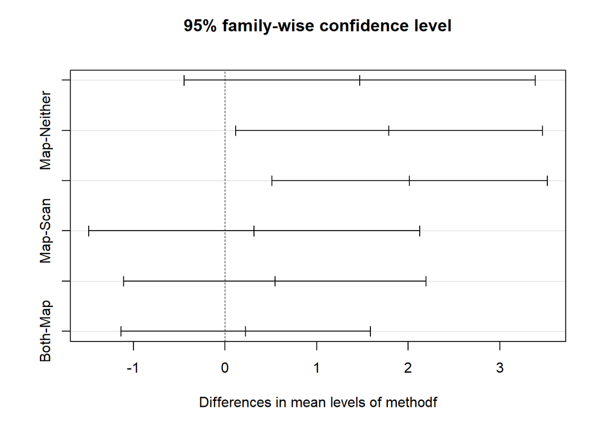

```r
plot(reading_mcomp)
```

На графике показаны 95% доверительные интервалы для разности средних в каждой паре сравниваемых групп. Только интервалы для пар Map-Neither и Both-Neither не включают 0, поэтому различия в этих группах являются статистически значимыми.

Для визуализации различий средствами `ggplot2` необходимо преобразовать результат сравнения в датафрейм. Для этого можно воспользоваться пакетом `broom`.

```r
reading_mcomp_df <- broom::tidy(reading_mcomp)
reading_mcomp_df
```

```
## # A tibble: 6 x 6
##   term    comparison   estimate conf.low conf.high adj.p.value
##   <chr>   <chr>           <dbl>    <dbl>     <dbl>       <dbl>
## 1 methodf Scan-Neither    1.47    -0.444      3.38     0.186
## 2 methodf Map-Neither     1.79     0.115      3.46     0.0321
## 3 methodf Both-Neither    2.01     0.512      3.52     0.00450
## 4 methodf Map-Scan        0.319   -1.49       2.12     0.965
## 5 methodf Both-Scan       0.545   -1.10       2.19     0.815
## 6 methodf Both-Map        0.226   -1.14       1.59     0.971
```

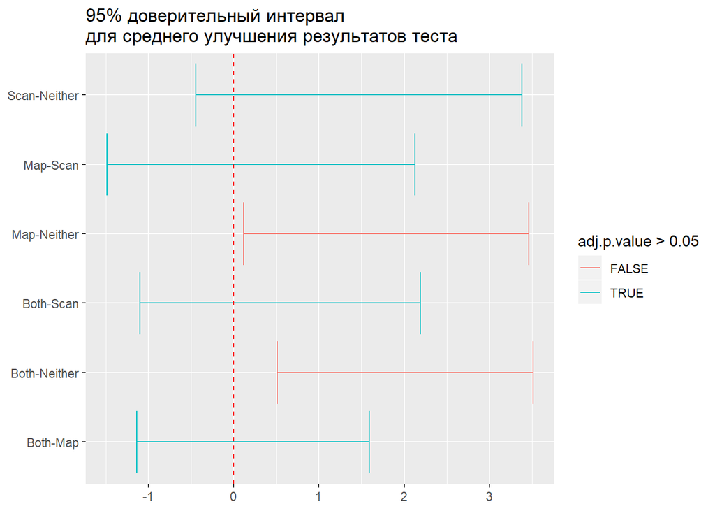

```r
ggplot(data = reading_mcomp_df, aes(x = comparison)) +
  geom_errorbar(aes(y = estimate,
                    ymin = conf.low,
                    ymax = conf.high,
                    color = adj.p.value > 0.05)) +
  geom_hline(yintercept = 0, color = 'red', linetype = 'dashed') +
  labs(x = NULL, y = NULL,
       title = '95% доверительный интервал\nдля среднего улучшения результатов теста') +
  coord_flip()
```